# pml project

ju-ok

11/12/2020

# Background

Using devices such as Jawbone Up, Nike FuelBand, and Fitbit it is now possible to collect a large amount of data about personal activity relatively inexpensively. These type of devices are part of the quantified self movement – a group of enthusiasts who take measurements about themselves regularly to improve their health, to find patterns in their behavior, or because they are tech geeks. One thing that people regularly do is quantify how much of a particular activity they do, but they rarely quantify how well they do it. In this project, your goal will be to use data from accelerometers on the belt, forearm, arm, and dumbell of 6 participants. They were asked to perform barbell lifts correctly and incorrectly in 5 different ways. Details: http://groupware.les.inf.puc-rio.br/har

## Data

The training data for this project can be accessed from: https://d396qusza40orc.cloudfront.net/predmachlearn/pml-training.csv  
The test data are also available at: https://d396qusza40orc.cloudfront.net/predmachlearn/pml-testing.csv

# Exploratory Data analysis

```r
# Load packages
library(caret)
# Load the data sets
training <- read.csv("./pml-training.csv")
testing <- read.csv("./pml-testing.csv")

# Explore data sets
# structure
str(training)
```

```
## 'data.frame':    19622 obs. of  160 variables:
##  $ X                       : int  1 2 3 4 5 6 7 8 9 10 ...
##  $ user_name               : chr  "carlitos" "carlitos" "carlitos" "carlitos" ...
##  $ raw_timestamp_part_1    : int  1323084231 1323084231 1323084231 1323084232 1323084232 1323084232 1323084232 1323084232 1323084232 1323084232 ...
##  $ raw_timestamp_part_2    : int  788290 808298 820366 120339 196328 304277 368296 440390 484323 484434 ...
##  $ cvtd_timestamp          : chr  "05/12/2011 11:23" "05/12/2011 11:23" "05/12/2011 11:23" "05/12/2011 11:23" ...
##  $ new_window              : chr  "no" "no" "no" "no" ...
##  $ num_window              : int  11 11 11 12 12 12 12 12 12 12 ...
##  $ roll_belt               : num  1.41 1.41 1.42 1.48 1.48 1.45 1.42 1.42 1.43 1.45 ...
##  $ pitch_belt              : num  8.07 8.07 8.07 8.05 8.07 8.06 8.09 8.13 8.16 8.17 ...
##  $ yaw_belt                : num  -94.4 -94.4 -94.4 -94.4 -94.4 -94.4 -94.4 -94.4 -94.4 -94.4 ...
##  $ total_accel_belt        : int  3 3 3 3 3 3 3 3 3 3 ...
##  $ kurtosis_roll_belt      : chr  "" "" "" "" ...
##  $ kurtosis_picth_belt     : chr  "" "" "" "" ...
##  $ kurtosis_yaw_belt       : chr  "" "" "" "" ...
```

[output cut: 86 more lines]

```r
# dimensions
dim(training)
```

```
## [1] 19622   160
```

# Clean the data

```r
# Clean the data sets

# remove columns with undesired info
training <- training[, -c(1:7)]
testing <- testing[, -c(1:7)]

# remove columns with NA
training <- training[, colSums(is.na(training)) == 0]
testing <- testing[, colSums(is.na(testing)) == 0]

# remove all character columns except classe
training <- training[, sapply(training[ , -86], is.numeric)]
testing <- testing[, sapply(testing[ , -86], is.numeric)]

# dimensions of the training and test data
dim(training); dim(testing)
```

```
## [1] 19622    53
```

```
## [1] 20 53
```

# Split the training data

The training data is split into 70% training set and 30% testing set.

```r
# Split training data into trainingset and testingset
set.seed(1222)

inTrain <- createDataPartition(y = training$classe,
                               p = 0.7,
                               list = FALSE)

trainingset <- training[inTrain, ]
testingset <- training[-inTrain, ]
```

# Fit models

## classification tree

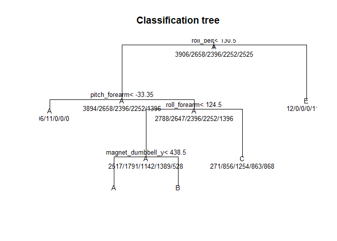

```r
# classification tree
modrpart <- train(classe ~., method = "rpart",  data = trainingset)

# plot the final model
plot(modrpart$finalModel, main = "Classification tree")
text(modrpart$finalModel, use.n = TRUE, all = TRUE, cex = 0.8)
```

```r
# predict using testingset
predrpart <- predict(modrpart, testingset)

# evaluate the model
confusionMatrix(predrpart, as.factor(testingset$classe))
```

```
## Confusion Matrix and Statistics
##
##           Reference
## Prediction    A    B    C    D    E
##          A 1521  450  488  440  138
##          B   24  302   16  169   67
##          C  127  387  522  355  375
##          D    0    0    0    0    0
##          E    2    0    0    0  502
##
## Overall Statistics
##
##                Accuracy : 0.4838
##                  95% CI : (0.4709, 0.4966)
##     No Information Rate : 0.2845
##     P-Value [Acc > NIR] : < 2.2e-16
##
##                   Kappa : 0.3262
##
##  Mcnemar's Test P-Value : NA
##
## Statistics by Class:
##
##                      Class: A Class: B Class: C Class: D Class: E
## Sensitivity            0.9086  0.26514   0.5088   0.0000  0.46396
## Specificity            0.6400  0.94185   0.7440   1.0000  0.99958
## Pos Pred Value         0.5008  0.52249   0.2956      NaN  0.99603
## Neg Pred Value         0.9463  0.84228   0.8776   0.8362  0.89221
## Prevalence             0.2845  0.19354   0.1743   0.1638  0.18386
## Detection Rate         0.2585  0.05132   0.0887   0.0000  0.08530
## Detection Prevalence   0.5161  0.09822   0.3001   0.0000  0.08564
## Balanced Accuracy      0.7743  0.60350   0.6264   0.5000  0.73177
```

## Generalized boosted model

```r
# gbm
control <- trainControl(method = "repeatedcv", number = 3, repeats = 1)
modgbm <- train(classe ~., method = "gbm",  data = trainingset,
                trControl = control, verbose = FALSE)
```

```r
# predict using testingset
predgbm <- predict(modgbm, testingset)

# evaluate
confusionMatrix(predgbm, as.factor(testingset$classe))
```

```
## Confusion Matrix and Statistics
##
##           Reference
## Prediction    A    B    C    D    E
##          A 1639   37    0    0    1
##          B   21 1072   34    6   15
##          C   10   27  983   39   12
##          D    3    3    6  917   18
##          E    1    0    3    2 1036
##
## Overall Statistics
##
##                Accuracy : 0.9596
##                  95% CI : (0.9542, 0.9644)
##     No Information Rate : 0.2845
##     P-Value [Acc > NIR] : < 2.2e-16
##
##                   Kappa : 0.9488
##
##  Mcnemar's Test P-Value : 2.303e-12
##
## Statistics by Class:
##
##                      Class: A Class: B Class: C Class: D Class: E
## Sensitivity            0.9791   0.9412   0.9581   0.9512   0.9575
## Specificity            0.9910   0.9840   0.9819   0.9939   0.9988
## Pos Pred Value         0.9773   0.9338   0.9178   0.9683   0.9942
## Neg Pred Value         0.9917   0.9859   0.9911   0.9905   0.9905
## Prevalence             0.2845   0.1935   0.1743   0.1638   0.1839
## Detection Rate         0.2785   0.1822   0.1670   0.1558   0.1760
## Detection Prevalence   0.2850   0.1951   0.1820   0.1609   0.1771
## Balanced Accuracy      0.9850   0.9626   0.9700   0.9726   0.9781
```

## random forest

```r
# rf
modrf <- train(classe ~., method = "rf", data = trainingset,
               trControl = trainControl(method = "cv"), number = 3)
```

```r
# predict using testingset
predrf <- predict(modrf, testingset)

# evaluate
confusionMatrix(predrf, as.factor(testingset$classe))
```

```
## Confusion Matrix and Statistics
##
##           Reference
## Prediction    A    B    C    D    E
##          A 1671    4    0    0    0
##          B    2 1132    5    0    0
##          C    0    3 1019   16    0
##          D    0    0    2  948    8
##          E    1    0    0    0 1074
##
## Overall Statistics
##
##                Accuracy : 0.993
##                  95% CI : (0.9906, 0.995)
##     No Information Rate : 0.2845
##     P-Value [Acc > NIR] : < 2.2e-16
##
##                   Kappa : 0.9912
##
##  Mcnemar's Test P-Value : NA
##
## Statistics by Class:
##
##                      Class: A Class: B Class: C Class: D Class: E
## Sensitivity            0.9982   0.9939   0.9932   0.9834   0.9926
## Specificity            0.9991   0.9985   0.9961   0.9980   0.9998
## Pos Pred Value         0.9976   0.9939   0.9817   0.9896   0.9991
## Neg Pred Value         0.9993   0.9985   0.9986   0.9968   0.9983
## Prevalence             0.2845   0.1935   0.1743   0.1638   0.1839
## Detection Rate         0.2839   0.1924   0.1732   0.1611   0.1825
## Detection Prevalence   0.2846   0.1935   0.1764   0.1628   0.1827
## Balanced Accuracy      0.9986   0.9962   0.9946   0.9907   0.9962
```

# Select and use best model

Based on the accuracy scores from the confusionMatrix, the random forest model has the highest accuracy followed by the generalized boosted model and classification tree respectively. The random forest model will be used on the `testing` data.

```r
predfinal <- predict(modrf, testing)
predfinal
```

```
##  [1] B A B A A E D B A A B C B A E E A B B B
## Levels: A B C D E
```